# Practical: Generalized Additive Models

Physalia workshop on GLMs

Bert van der Veen

# Background

GLMs assume that covariates enter the linear predictor **linearly**: a one-unit change in $x$ always produces the same change in $g\{\text{E}(y)\}$, regardless of where on the $x$-axis you are. Many ecological relationships are non-linear, and a linear model misspecifies the functional form, leading to systematic residual patterns.

Generalized Additive Models (GAMs) replace the linear term $x\beta$ with a smooth function $f(x)$ estimated from the data. The two main packages for fitting GAMs in R are:

- `mgcv`: the standard GAM package by Simon Wood
- `gratia`: provides `ggplot2`-based visualisation tools for `mgcv` models

In this practical we will use the ISIT dataset (bioluminescent sources at depth in the ocean) from Gillibrand et al. (2007), the same dataset used in the lecture.

```r
library(mgcv)
library(gratia)

ISIT <- read.csv("../../data/ISIT.csv")
str(ISIT)
```

```
## 'data.frame':    789 obs. of  14 variables:
##  $ SampleDepth  : num  517 582 547 614 1068 ...
##  $ Sources      : num  28.7 27.9 23.4 18.3 12.4 ...
##  $ Station      : int  1 1 1 1 1 1 1 1 1 1 ...
##  $ Time         : int  3 3 3 3 3 3 3 3 3 3 ...
##  $ Latitude     : num  50.2 50.2 50.2 50.2 50.2 ...
##  $ Longitude    : num  -14.5 -14.5 -14.5 -14.5 -14.5 ...
##  $ Xkm          : num  -34.1 -34.1 -34.1 -34.1 -34.1 ...
##  $ Ykm          : num  16.8 16.8 16.8 16.8 16.8 ...
##  $ Month        : int  4 4 4 4 4 4 4 4 4 4 ...
##  $ Year         : int  2001 2001 2001 2001 2001 2001 2001 2001 2001 2001 ...
##  $ BottomDepth  : int  3939 3939 3939 3939 3939 3939 3939 3939 3939 3939 ...
##  $ Season       : int  1 1 1 1 1 1 1 1 1 1 ...
##  $ Discovery    : int  252 252 252 252 252 252 252 252 252 252 ...
##  $ RelativeDepth: num  3422 3357 3392 3325 2871 ...
```

The response is `Sources` (count of bioluminescent organisms), and the main predictor is `SampleDepth` (depth in metres). There are 19 stations; for now we will focus on a single station.

```r
dat <- subset(ISIT, Station == 9)
nrow(dat)
```

```
## [1] 54
```

# Distribution of the response

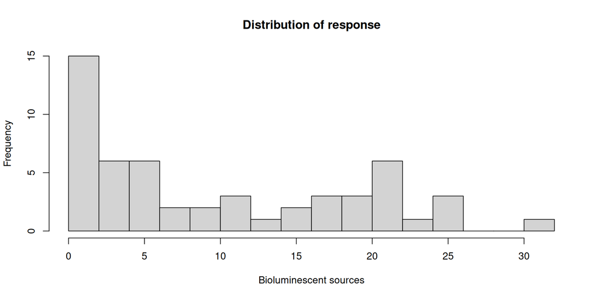

```r
hist(dat$Sources, breaks=20,
     xlab="Bioluminescent sources", main="Distribution of response")
```

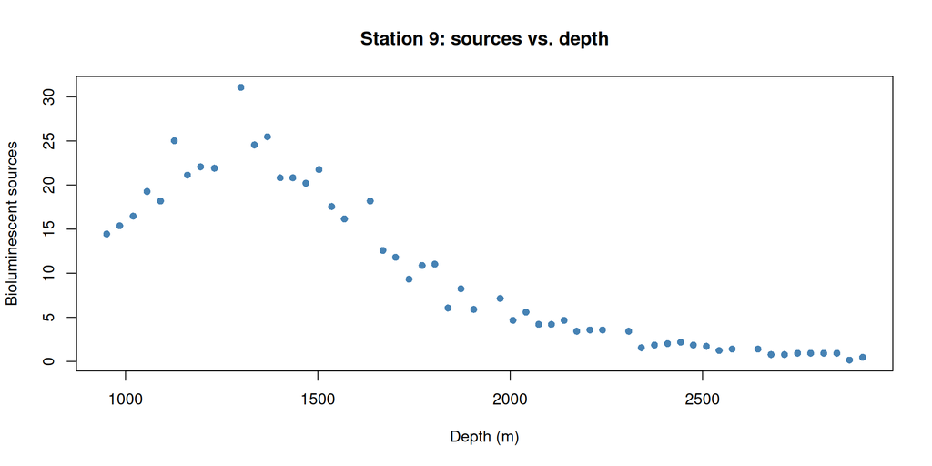

```r
plot(Sources ~ SampleDepth, data=dat, pch=16, col="steelblue",
     xlab="Depth (m)", ylab="Bioluminescent sources",
     main="Station 9: sources vs. depth")
```

Does the relationship look linear? What distribution might be appropriate for the response?

# A GLM baseline

Let us first fit a Gamma GLM with a log link, treating depth as a linear predictor.

```r
m_glm <- glm(Sources ~ SampleDepth, family=Gamma(link="log"), data=dat)
summary(m_glm)
```

```
##
## Call:
## glm(formula = Sources ~ SampleDepth, family = Gamma(link = "log"),
##     data = dat)
##
## Coefficients:
##               Estimate Std. Error t value Pr(>|t|)
## (Intercept)  5.862e+00  1.518e-01   38.61   <2e-16 ***
## SampleDepth -2.123e-03  7.503e-05  -28.30   <2e-16 ***
## ---
## Signif. codes:  0 '***' 0.001 '**' 0.01 '*' 0.05 '.' 0.1 ' ' 1
##
## (Dispersion parameter for Gamma family taken to be 0.1032109)
##
##     Null deviance: 65.7320  on 53  degrees of freedom
## Residual deviance:  7.3897  on 52  degrees of freedom
## AIC: 234.39
##
## Number of Fisher Scoring iterations: 6
```

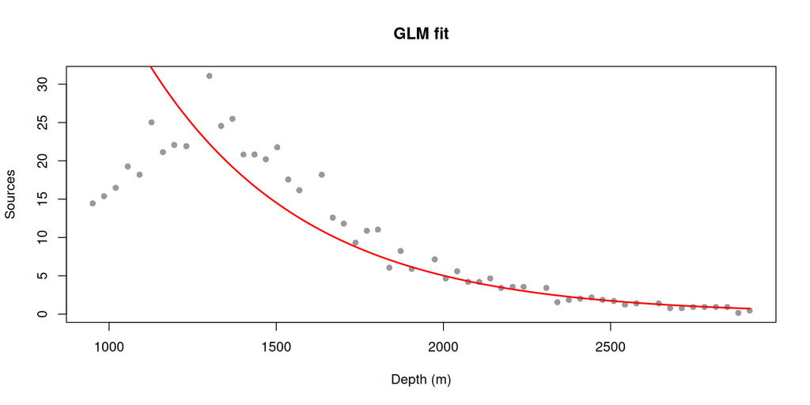

```r
xseq <- seq(min(dat$SampleDepth), max(dat$SampleDepth), length.out=300)
pred_glm <- predict(m_glm, newdata=data.frame(SampleDepth=xseq), type="response")

plot(Sources ~ SampleDepth, data=dat, pch=16, col="gray60",
     xlab="Depth (m)", ylab="Sources", main="GLM fit")
lines(xseq, pred_glm, col="red", lwd=2)
```

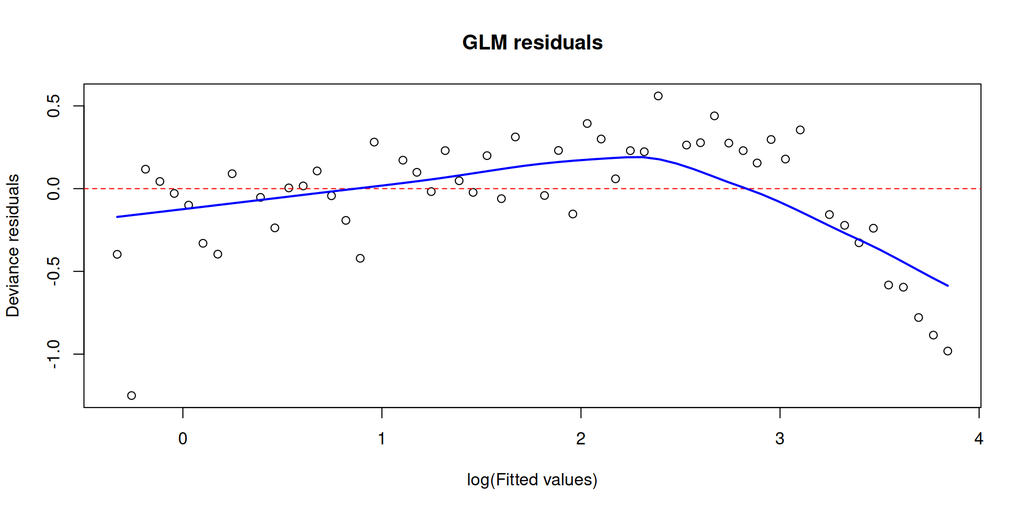

```r
plot(log(fitted(m_glm)), residuals(m_glm, type="deviance"),
     xlab="log(Fitted values)", ylab="Deviance residuals",
     main="GLM residuals")
abline(h=0, lty="dashed", col="red")
lines(loess.smooth(log(fitted(m_glm)), residuals(m_glm, type="deviance")),
      col="blue", lwd=2)
```

The pattern in the residuals suggests the linear predictor does not capture the shape of the relationship.

# Fitting a GAM

We now fit a GAM with a smooth term for `SampleDepth`. We use `bs="cr"` (cubic regression spline) and `method="REML"` for smoothing parameter selection.

```r
m_gam <- gam(Sources ~ s(SampleDepth, bs="cr"),
             family=Gamma(link="log"), data=dat, method="REML")
summary(m_gam)
```

```
##
## Family: Gamma
## Link function: log
##
## Formula:
## Sources ~ s(SampleDepth, bs = "cr")
##
## Parametric coefficients:
##             Estimate Std. Error t value Pr(>|t|)
## (Intercept)  1.70174    0.02749    61.9   <2e-16 ***
## ---
## Signif. codes:  0 '***' 0.001 '**' 0.01 '*' 0.05 '.' 0.1 ' ' 1
##
## Approximate significance of smooth terms:
##                  edf Ref.df     F p-value
## s(SampleDepth) 5.358  6.472 310.6  <2e-16 ***
## ---
## Signif. codes:  0 '***' 0.001 '**' 0.01 '*' 0.05 '.' 0.1 ' ' 1
##
## R-sq.(adj) =  0.964   Deviance explained = 96.2%
## -REML = 96.374  Scale est. = 0.040807  n = 54
```

The `edf` column in the smooth terms table shows the **effective degrees of freedom**: a measure of how wiggly the estimated smooth is. An edf of 1 is a straight line; higher values indicate more curvature.

## Plotting the smooth with gratia

The `gratia` package provides `draw()` for visualising GAM smooths with confidence intervals.

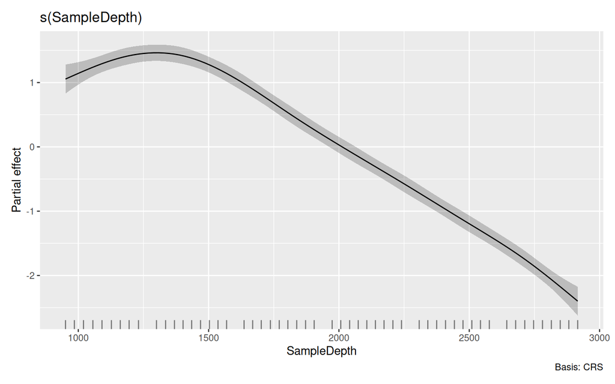

```r
draw(m_gam)
```

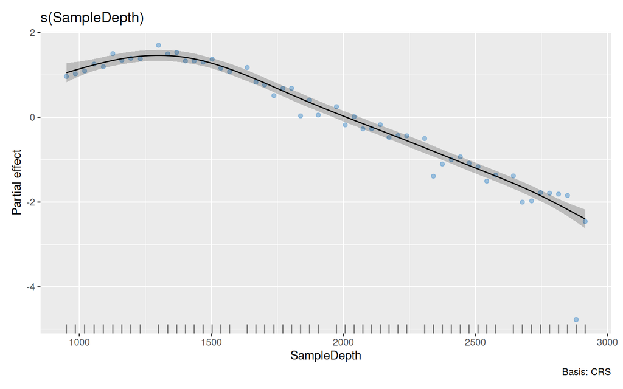

```r
draw(m_gam, residuals=TRUE)
```

# Model checking

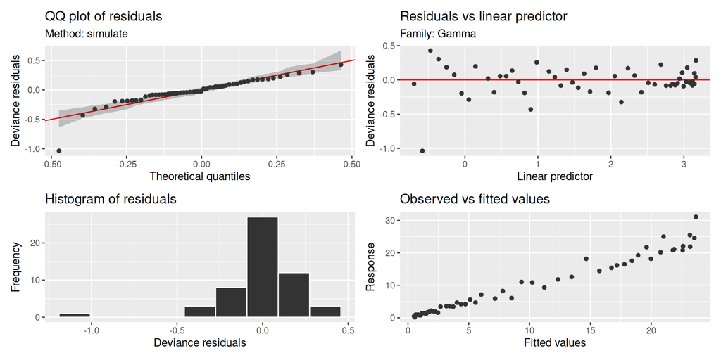

```r
appraise(m_gam, method="simulate")
```

# Comparing GLM and GAM

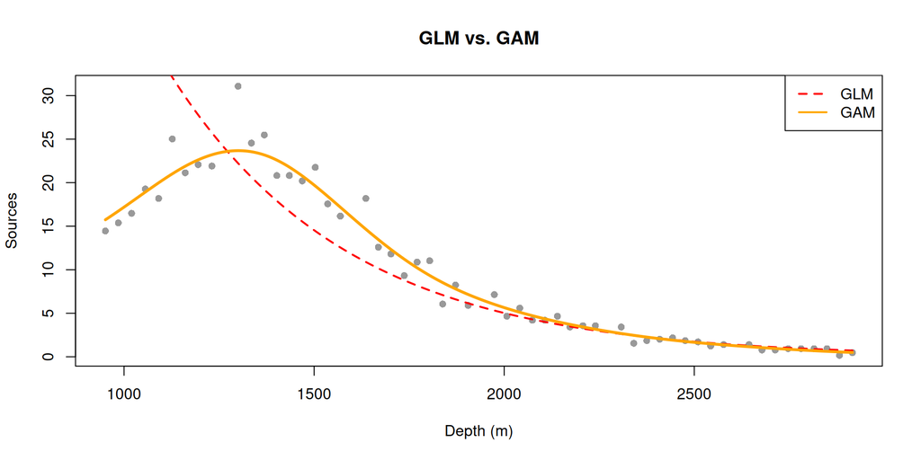

```r
pred_gam <- predict(m_gam, newdata=data.frame(SampleDepth=xseq), type="response")

plot(Sources ~ SampleDepth, data=dat, pch=16, col="gray60",
     xlab="Depth (m)", ylab="Sources", main="GLM vs. GAM")
lines(xseq, pred_glm, col="red", lwd=2, lty="dashed")
lines(xseq, pred_gam, col="orange", lwd=3)
legend("topright", lty=c("dashed","solid"), col=c("red","orange"),
       legend=c("GLM", "GAM"), lwd=2)
```

```r
AIC(m_glm, m_gam)
```

```
##             df      AIC
## m_glm 3.000000 234.3887
## m_gam 7.890603 184.6814
```

# Extending to all stations

The ISIT data has 19 stations, and observations from the same station are not independent. We can extend the GAM to include a random intercept for station, giving a GAMM (Generalized Additive Mixed Model).

```r
# Full dataset includes zeros so we use Tweedie
m_gamm <- gam(Sources ~ s(SampleDepth, bs="cr") + s(Station, bs="re"),
              family=tw(), data=ISIT, method="REML")
summary(m_gamm)
```

```
##
## Family: Tweedie(p=1.621)
## Link function: log
##
## Formula:
## Sources ~ s(SampleDepth, bs = "cr") + s(Station, bs = "re")
##
## Parametric coefficients:
##             Estimate Std. Error t value Pr(>|t|)
## (Intercept)  1.34884    0.04978    27.1   <2e-16 ***
## ---
## Signif. codes:  0 '***' 0.001 '**' 0.01 '*' 0.05 '.' 0.1 ' ' 1
##
## Approximate significance of smooth terms:
##                   edf Ref.df      F p-value
## s(SampleDepth) 8.1128  8.769 363.74  <2e-16 ***
## s(Station)     0.9838  1.000  60.74  <2e-16 ***
## ---
## Signif. codes:  0 '***' 0.001 '**' 0.01 '*' 0.05 '.' 0.1 ' ' 1
##
## R-sq.(adj) =   0.64   Deviance explained = 79.6%
## -REML = 2015.1  Scale est. = 0.64349   n = 789
```

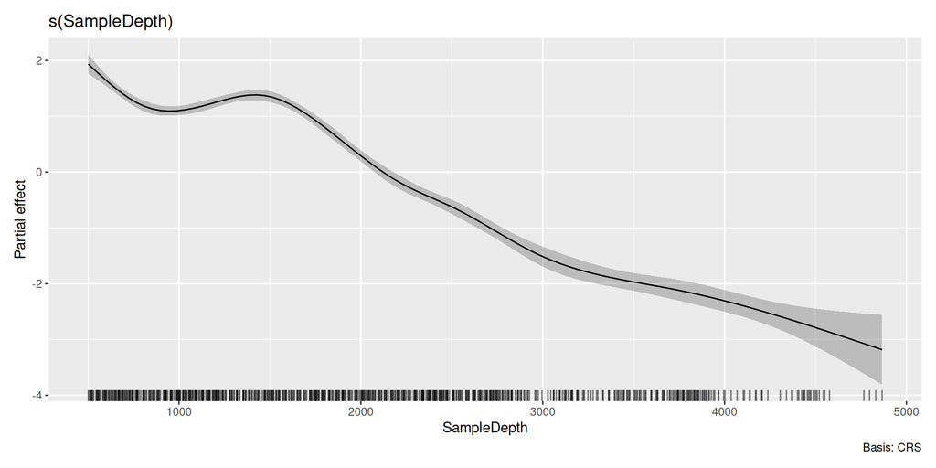

```r
draw(m_gamm, select=1)
```

How does the depth smooth change when you include all stations compared to fitting only Station 9?

# Exercises

**Click to see the exercises**

1. Refit the GAM for Station 9 with a thin plate spline (`bs="tp"`, the default) instead of `bs="cr"`. Does the fitted smooth look different? Compare AIC.
2. Fit a GAM to Station 9 using a Poisson family instead of Gamma. Check the diagnostics with `gratia::appraise()`. Does a Poisson distribution seem appropriate?
3. For the full ISIT dataset, fit a model with a station-specific smooth for depth: `s(SampleDepth, by=factor(Station), bs="cr", k=5)`. Note that some stations have very few observations (Station 4 has only 5), so a small `k` is needed to avoid fitting problems. How does this compare (AIC) to the model with a global smooth plus random intercept?
4. Use `gratia::appraise()` on your best model. Are there any remaining problems?
5. Try the same GAMM in `glmmTMB`:

```r
library(glmmTMB)
m_tmb <- glmmTMB(Sources ~ s(SampleDepth, bs="cr") + (1|Station),
                 family=Gamma(link="log"), data=ISIT)
```

Compare the predicted smooth from `glmmTMB` and `mgcv`. Are they similar?

6. The dataset has a `Season` column. Add `Season` as a factor to the GAMM. Does the seasonal effect improve the model?